# Part I - Exploratory Data Analysis (Loan Data From Prosper)

## by Oluwatobi Adebanwo

## Introduction

This project contains exploratory data analysis of a [**Loan Data**](https://www.google.com/url?q=https://s3.amazonaws.com/udacity-hosted-downloads/ud651/prosperLoanData.csv&sa=D&ust=1581581520570000). Exploratory data analysis involves using Python data science and data visualization libraries to explore a dataset’s discoveries, variables and understand the data’s structure, oddities, patterns, and relationships.

The Loan dataset contains 113,937 loans with 81 variables on each loan, including loan amount, borrower rate (or interest rate), current loan status, borrower income, and many others. The [**data dictionary**](https://docs.google.com/spreadsheets/d/1gDyi_L4UvIrLTEC6Wri5nbaMmkGmLQBk-Yx3z0XDEtI/edit#gid=0) explains the variables in the dataset. I will be using various visualizations to observe insights and trends into the dataset in Univariate, Bivariate and Multivariate Exploration.

### **Let's look at the Income Range of loan borrowers**

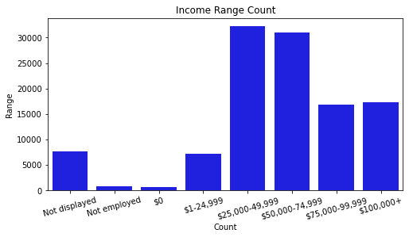

It can be seen that the highest income ranges from 25,000 dollars to 49,999 dollars with Not employed individuals having the little or no income. Some Income Ranges were not displayed.

### **A look at an overview of Loan amount collected by persons over this period**

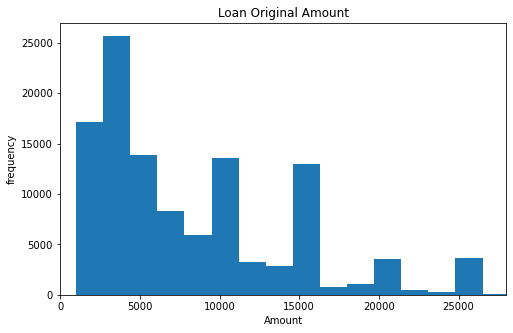

It shows that loan original amount is right skewed with most loan collected ranging from 0 to 5000 dollars and decreasing upwards to 25000 dollars. About more than 3000 records of loan of $25000.

### **We'll take a Look at the Status of Loans**

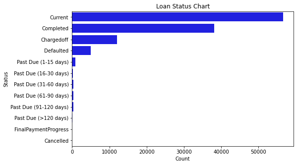

From the Visualization above, majority of the Loan are still in Current status. Although, a higher percentage of the loan have been charged off. Charge-off means the lender or creditor has written the account off as a loss, and the account is closed to future charges. Over 1000 loans are defaulted, these are failure to repay a loan according to the terms agreed to in the promissory note. A large amount of the Loan have also been completed with very few loans that are Past Due

### **Let's look at the Relationship between Income range and Income Verified data**

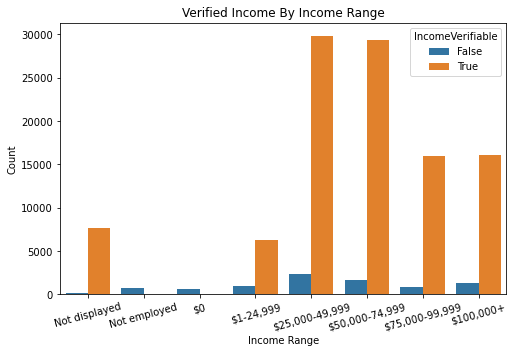

### **We will look into Loan amount and Year**

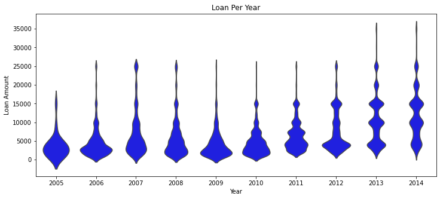

### **We shall compare loan amount and monthly payment over each loan duration**

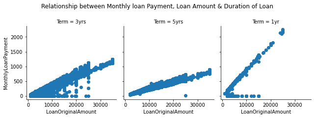

This visualization shows that most loans were collected over a period of 3 years with lower monthly payment compared to loans collected over a 1 year deal that had higher monthly loan payement. Generally, Monthly Loan Payment Increases with Loan original amount

### **Let's Look at the Relationships between 3 variables, Loan amount, monthly payment and Investors.**

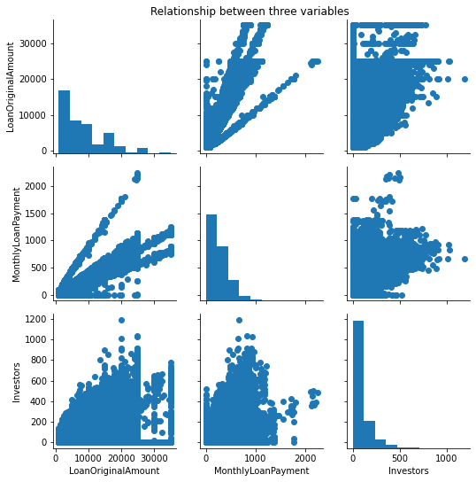